# Collecting and Exploring Fitbit Data

## Full Documentation:

[Python Fitbit](https://python-fitbit.readthedocs.io/en/latest/)

## Code:

[Fitbit Github Repo](https://github.com/mrkaye97/Fitbit/)

## Description:

This repository contains two python files, `data_pull.py` and `gather_keys_oauth2.py`. `data_pull.py` hooks into the Fitbit API (with a given client ID and secret) and pulls Fitbit statistics.

The R files in `/viz/sleep/` and `/viz/activity/` visualize my Fitbit data.

## The Data:

```r
PROJECT_ROOT <- find_root('fitbit.Rproj')
```

```r
con <- DBI::dbConnect(RPostgres::Postgres(),
                      host = "localhost",
                      dbname = "fitbit",
                      user = "matt")
```

```r
activity <- tbl(con, 'basicactivity') %>%
  data.frame() %>%
  arrange(date)

water <- tbl(con, 'water') %>%
  data.frame() %>%
  arrange(date)

sleep <- tbl(con, 'sleep') %>%
  data.frame() %>%
  arrange(date)

df <- activity %>%
  left_join(water, by = 'date') %>%
  left_join(sleep, by = 'date')

df %>%
  glimpse()
```

```
## Rows: 325
## Columns: 22
## $ date                 <date> 2019-11-09, 2019-11-10, 2019-11-11, 2019-11-12,…
## $ activityCalories     <int64> 953, 1199, 2087, 696, 2679, 1531, 2785, 3849, …
## $ caloriesBMR          <int64> 1879, 1879, 1878, 1878, 1877, 1877, 1877, 1877…
## $ caloriesOut          <int64> 2637, 2839, 3690, 2473, 4204, 3264, 4147, 5183…
## $ marginalCalories     <int64> 471, 665, 1357, 340, 1840, 1015, 1705, 2722, 8…
## $ sedentaryMinutes     <int64> 727, 1184, 470, 535, 532, 657, 466, 330, 580, …
## $ lightlyActiveMinutes <int64> 228, 236, 220, 173, 262, 153, 393, 206, 243, 1…
## $ fairlyActiveMinutes  <int64> 0, 10, 44, 0, 31, 41, 61, 116, 15, 32, 1, 39, …
## $ veryActiveMinutes    <int64> 0, 10, 82, 0, 102, 52, 59, 205, 24, 83, 42, 77…
## $ restingHeartRate     <int64> 59, 59, 56, 56, 57, 58, 59, 60, 61, 61, 61, 61…
## $ steps                <int64> 5265, 7896, 10799, 3322, 16089, 10880, 19935, …
## $ water                <int64> 0, 0, 0, 0, 0, 0, 0, 0, 0, 0, 0, 0, 0, 0, 0, 0…
## $ mainSleep            <lgl> TRUE, NA, TRUE, TRUE, TRUE, TRUE, TRUE, TRUE, TR…
## $ startTime            <chr> "2019-11-08T22:55:00.000", NA, "2019-11-10T22:01…
## $ endTime              <chr> "2019-11-09T07:00:30.000", NA, "2019-11-11T06:35…
## $ minutesAsleep        <int64> 453, NA, 470, 581, 466, 521, 423, 502, 521, 39…
## $ minutesAwake         <int64> 32, NA, 41, 30, 38, 16, 11, 25, 20, 38, 49, 22…
## $ awakenings           <int64> 2, NA, 4, 0, 1, 0, 0, 2, 0, 1, 1, 0, 0, 1, 1, …
## $ restlessCount        <int64> 16, NA, 15, 21, 17, 11, 2, 10, 12, 14, 20, 13,…
## $ restlessDuration     <int64> 30, NA, 37, 37, 36, 16, 2, 20, 20, 35, 43, 22,…
## $ timeInBed            <int64> 485, NA, 514, 618, 504, 537, 434, 527, 541, 42…
## $ efficiency           <int64> 93, NA, 92, 95, 92, 97, 97, 95, 96, 91, 90, 95…
```

## Plot Example:

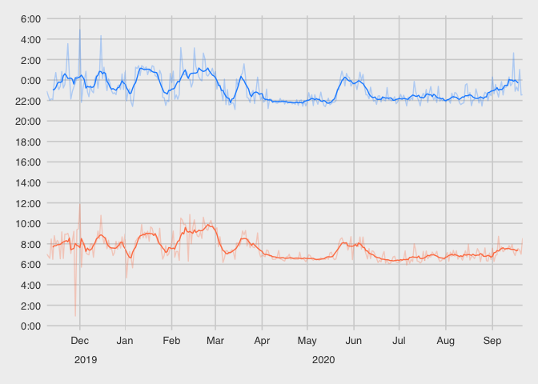

```r
df <- tbl(con, 'sleep') %>%
  arrange(date) %>%
  filter(mainSleep == TRUE) %>% # main sleep = no naps
  collect() %>%
  mutate(date = as_date(date),
         endTime = as_datetime(endTime),
         startTime = as_datetime(startTime),
         sh = ifelse(hour(startTime) < 8, hour(startTime) + 24, hour(startTime)), #create numeric times
         sm = minute(startTime),
         st = sh + sm/60,
         eh = hour(endTime),
         em = minute(endTime),
         et = eh + em/60,
         mst = ma(st, 7), #create moving averages
         met = ma(et, 7),
         year = year(startTime)
  )

plt <- df %>%
    ggplot(aes(x = date))+
    geom_line(aes(y = et), color = 'coral', alpha = .3, na.rm = T)+
    geom_line(aes(y = st), color = 'dodgerblue', alpha = .3, na.rm = T)+
    geom_line(aes(y = met), color = 'coral', na.rm=T)+
    geom_line(aes(y = mst), color = 'dodgerblue', na.rm=T)+
    scale_y_continuous(breaks = seq(0, 30, 2),
                       labels = trans_format(function(x) ifelse(x > 23, x - 24, x),
                                             format = scales::comma_format(suffix = ":00", accuracy = 1))
    )+
    labs(x = "Date",
         y = 'Time')+
    theme_fivethirtyeight()+
  scale_x_date(date_breaks = '1 month', date_labels = '%b', expand = c(0, 0))+
  facet_grid(. ~ year, space = 'free', scales = 'free_x', switch = 'x') +
  theme(panel.spacing.x = unit(0,"line"),
        strip.placement = "outside")
```

## Methods:

**hr()** for minute-by-minute heart rate data, given a date

**sleep()** for all sleep logs, including time slept, start and end times, nap / main sleep, restless count, etc., given a date

**water()** for how much water was logged, given a date

**basicactivity()** for data on steps, active minutes, sedentary minutes, etc., given a date

**hrzones()** for data on how long was spent in each heart rate zone (peak, cardio, fat burn, other), given a date

**fill_missing_data()** will call all five above methods for a specified date range, and is meant to be run if the program doesn’t execute on some day or set of days

**date_check()** ensures no duplicates in the database

**daterange()** is a helper method to yield a range of dates (analogous to the range() function, but for dates)

All date parameters for each method defaults to the previous day. All methods (except for daterange() and date_check()) do not return. If date_check() returns -1, then the method that called it returns None and nothing is uploaded to the SQL database. Otherwise, new rows are appended to a SQL table in database fitbit with the specified name.

## Setup and Use:

This project **not** runnable or useful (unless you want my Fitbit data) without registering an application with the Fitbit API and getting your own client ID and secret. Steps to get set up:

1. First, [**go here**](https://towardsdatascience.com/collect-your-own-fitbit-data-with-python-ff145fa10873) and follow the instructions to authorize yourself to use the API.
2. **SAVE YOUR CLIENT ID AND CLIENT SECRET!** You’ll need them in the next step.
3. Then, in data_pull.py, change the database parameters (username, ip, name) to whatever PostreSQL database you want to use for storing the data if you don’t want to use localhost.
4. Run data_pull.py and give it a test run!

## Command Line Arguments:

–s (start date for fill in format %Y-%m-%d without quotation marks. If not set, defaults to one week ago.)

–id YOUR_CLIENT_ID (from step 2) – code will fail without a client ID

–sec YOUR_CLIENT_SECRET (from step 2) – code will fail without a secret